# Train Model Identify Single User

Head the dataset of all emails and create a subset to train on a single user, selected arbitrarily from users who sent a lot of emails. Set the random seed so we are repeatable.

```r
set.seed(3456)
source('../src/format_utils.R')
headers <- load_headers('headers.csv')
email.addr <- "kay.mann@enron.com"  # 16735 emails
# email.addr <- "steven.kean@enron.com" # 6759 emails - Vice President and Chief of Staff
# email.addr <- "kenneth.lay@enron.com" # 36 emails
# email.addr <- "phillip.allen@enron.com" # 2195 emails
# email.addr <- "mike.carson@enron.com" # 721 emails
# email.addr <- "john.griffith@enron.com" # 392 emails
source('../src/single_user_model.R')
emails.from <- get_emails_from(headers, email.addr)
emails.not.from <- get_random_emails_not_from(headers, email.addr, nrow(emails.from))
rm(headers)
emails.from$is.user <- 'Yes'
emails.not.from$is.user <- 'No'
emails <- rbind(emails.from, emails.not.from) %>%
   select(is.user, word.count, avg.word.length, num.lines,
          sentiment, num.recipients, p.punct.char,
          p.alpha.char, p.numeric.char, wday, hour)
emails$is.user <- as.factor(emails$is.user)
```

```r
require(caret)
require(AppliedPredictiveModeling)
```

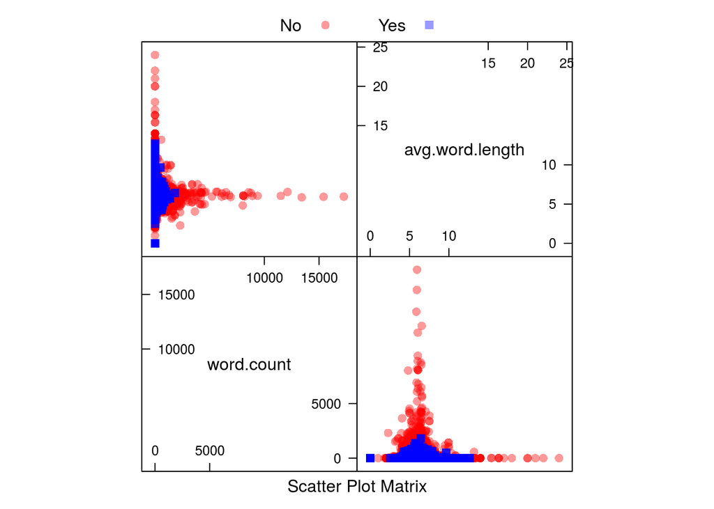

```r
transparentTheme(trans = .4)
plotPairs <- function(indx) {
  i <- 2*indx; j <- i+1
  featurePlot(x = emails[, i:j],
              y = emails$is.user,
              plot = "pairs",
              auto.key = list(columns = 2))
}
plotPairs(1)
```

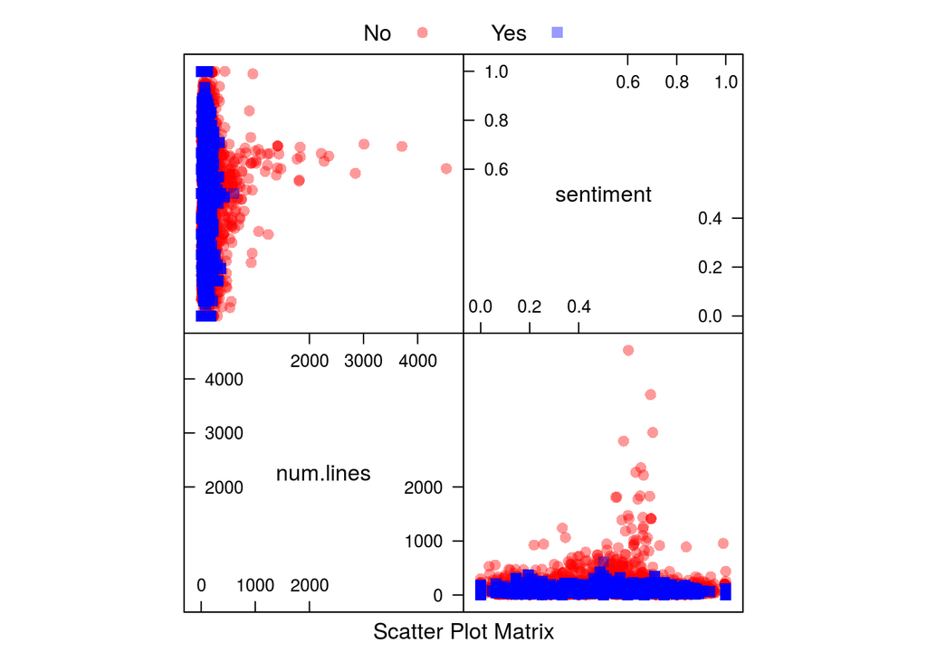

```r
plotPairs(2)
```

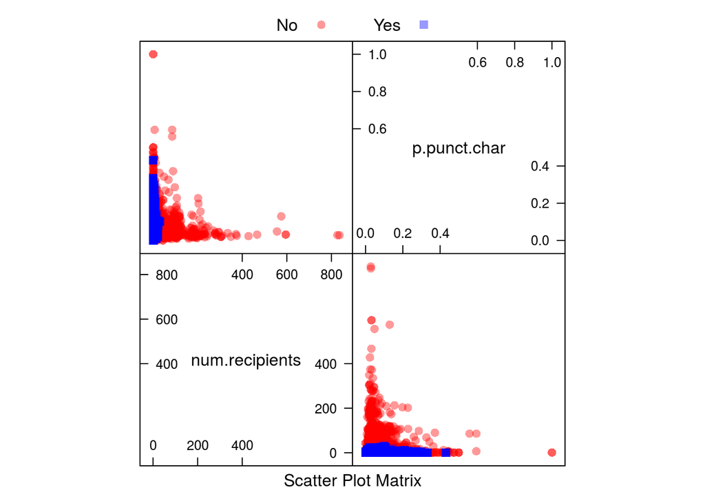

```r
plotPairs(3)
```

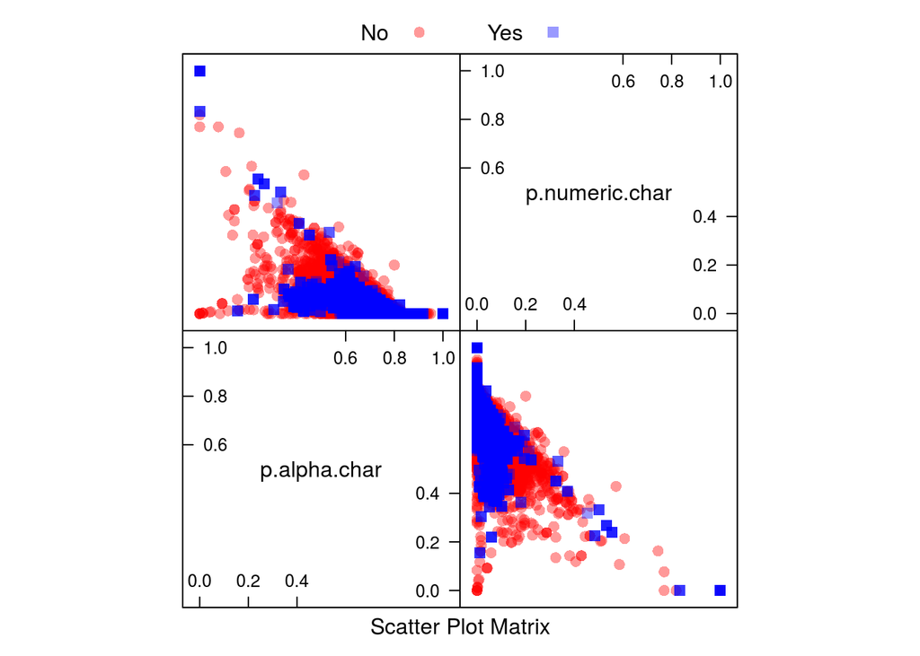

```r
plotPairs(4)
```

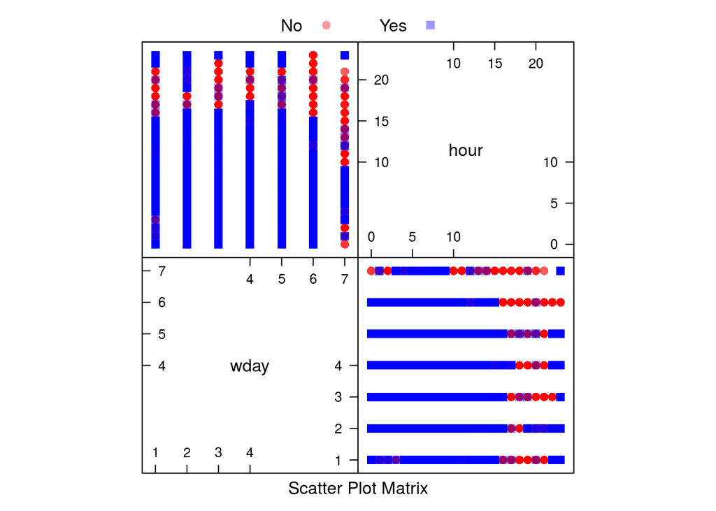

```r
plotPairs(5)
```

Split into training and test set. The center and scale predictors based on the training set.

```r
train.idx <- createDataPartition(emails$is.user, p = .8,
                                  list = FALSE,
                                  times = 1)
emails.train <- emails[train.idx,]
emails.test <- emails[-train.idx,]
prepro <- preProcess(emails.train, method = c("center", "scale"))
train <- predict(prepro, emails.train)
test <- predict(prepro, emails.test)
```

Do a PCA visualization to see if there are natural clusters.

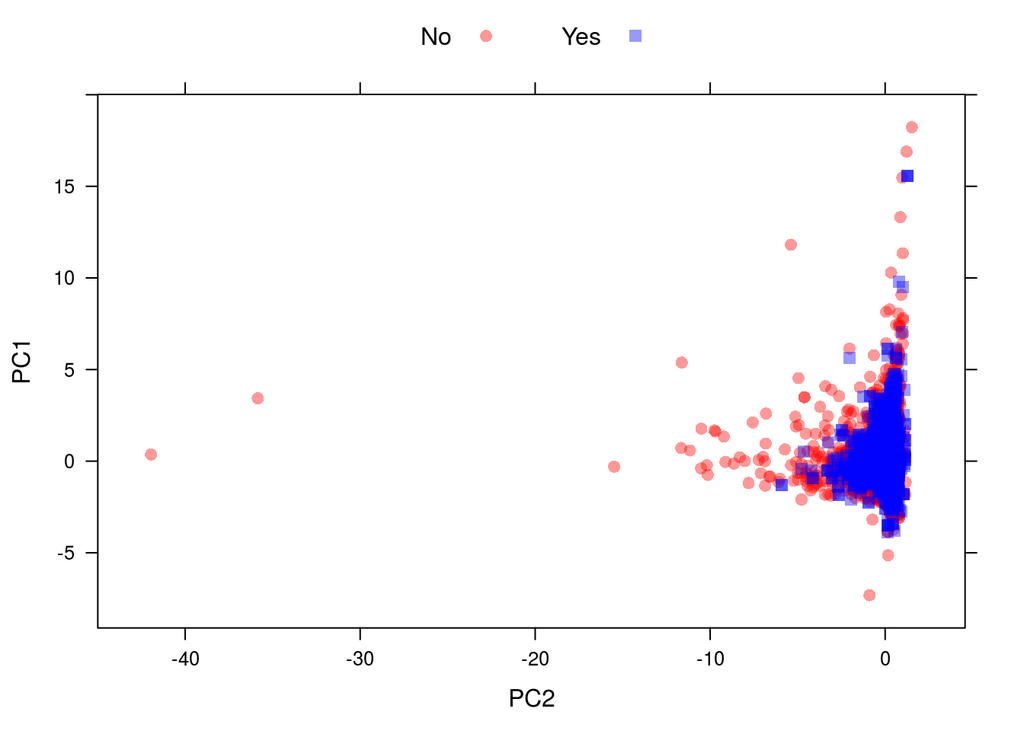

```r
prepro <- preProcess(emails.train, method="pca", pcaComp=2)
train.pca <- predict(prepro, emails.train)
test.pca <- predict(prepro, emails.test)
xyplot(PC1 ~ PC2,
       data = test.pca,
       groups = is.user,
       auto.key = list(columns = 2))
```

Fit a logistic regression model.

```r
lr.model <- glm(is.user ~.,family=binomial(link='logit'), data=train)
lr.model
```

```
##
## Call:  glm(formula = is.user ~ ., family = binomial(link = "logit"),
##     data = train)
##
## Coefficients:
##     (Intercept)       word.count  avg.word.length        num.lines
##        -0.21539         -2.24739         -0.20292          1.73577
##       sentiment   num.recipients     p.punct.char     p.alpha.char
##         0.09456         -1.89866          0.26335          0.03147
##  p.numeric.char             wday             hour
##        -0.47712         -0.06172         -0.38819
##
## Degrees of Freedom: 26348 Total (i.e. Null);  26338 Residual
## Null Deviance:       36520
## Residual Deviance: 31660     AIC: 31680
```

Fit a basic random forest model

```r
rf.model <- train(is.user ~ ., method='rf', data=train)
rf.model
```

```
## Random Forest
##
## 26349 samples
##    10 predictors
##     2 classes: 'No', 'Yes'
##
## No pre-processing
## Resampling: Bootstrapped (25 reps)
## Summary of sample sizes: 26349, 26349, 26349, 26349, 26349, 26349, ...
## Resampling results across tuning parameters:
##
##   mtry  Accuracy   Kappa
##    2    0.8800156  0.7595675
##    6    0.8766498  0.7527988
##   10    0.8726721  0.7447963
##
## Accuracy was used to select the optimal model using the largest value.
## The final value used for the model was mtry = 2.
```

Train a gradient boosting machine (GBM) with 10-folder cross-validation over 10 resamplings. Reset the seed so results are consistent. See [Caret Reference](http://topepo.github.io/caret/model-training-and-tuning.html). GBMs report [good results for two classes](http://fastml.com/what-is-better-gradient-boosted-trees-or-random-forest/) but require more tuning than random forests. Parallelize across 14 of my 16 CPU Cores and search for optimal parameter settings

```r
require(doMC)
registerDoMC(cores = 14)
fitControl <- trainControl(method = "repeatedcv",
                           number = 10,
                           repeats = 10,
                           allowParallel=TRUE)
gbmGrid <-  expand.grid(interaction.depth = c(5, 7, 10),
                        n.trees = (1:3)*50,
                        shrinkage = c(0.5, 0.1),
                        n.minobsinnode = c(5,10, 15))
set.seed(2531)
gbm.model <- train(is.user ~ ., data = train,
                   method = "gbm",
                   trControl = fitControl,
                   verbose = FALSE,
                   tuneGrid = gbmGrid)
gbm.model
```

```
## Stochastic Gradient Boosting
##
## 26349 samples
##    10 predictors
##     2 classes: 'No', 'Yes'
##
## No pre-processing
## Resampling: Cross-Validated (10 fold, repeated 10 times)
## Summary of sample sizes: 23714, 23715, 23714, 23714, 23714, 23713, ...
## Resampling results across tuning parameters:
##
##   shrinkage  interaction.depth  n.minobsinnode  n.trees  Accuracy
##   0.1         5                  5               50      0.7295950
##   0.1         5                  5              100      0.7490189
##   0.1         5                  5              150      0.7590155
##   0.1         5                 10               50      0.7297810
##   0.1         5                 10              100      0.7483660
##   0.1         5                 10              150      0.7582981
##   0.1         5                 15               50      0.7297088
##   0.1         5                 15              100      0.7486924
##   0.1         5                 15              150      0.7580248
##   0.1         7                  5               50      0.7386958
##   0.1         7                  5              100      0.7582374
##   0.1         7                  5              150      0.7670992
##   0.1         7                 10               50      0.7389159
##   0.1         7                 10              100      0.7580210
##   0.1         7                 10              150      0.7672814
##   0.1         7                 15               50      0.7388326
##   0.1         7                 15              100      0.7575239
##   0.1         7                 15              150      0.7673307
##   0.1        10                  5               50      0.7500207
##   0.1        10                  5              100      0.7672320
##   0.1        10                  5              150      0.7771679
##   0.1        10                 10               50      0.7495995
##   0.1        10                 10              100      0.7670005
##   0.1        10                 10              150      0.7776158
##   0.1        10                 15               50      0.7492313
##   0.1        10                 15              100      0.7668980
##   0.1        10                 15              150      0.7776271
##   0.5         5                  5               50      0.7613191
```

[output cut: 70 more lines]

```
##   0.5671360
##   0.5899014
##   0.5555776
##   0.5921255
##   0.6201500
##   0.5546946
##   0.5920419
##   0.6191304
##   0.5521737
##   0.5906480
##   0.6160355
##
## Accuracy was used to select the optimal model using the largest value.
## The final values used for the model were n.trees = 150,
##  interaction.depth = 10, shrinkage = 0.5 and n.minobsinnode = 5.
```

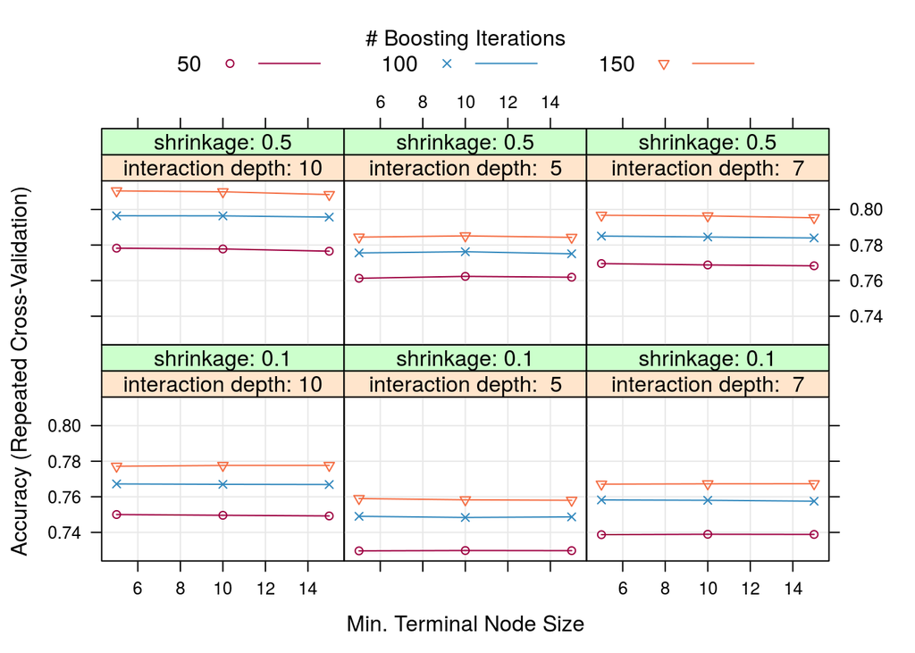

```r
trellis.par.set(caretTheme())
plot(gbm.model)
```

# Variable Importance

If this is any indication, the percentages of characters distinguish these people. We see for example that sentiment and day of the week probably isn’t important. The percentage of different types of characters, time of day, etc., is important.

```r
varImp(rf.model)
```

```
## rf variable importance
##
##                 Overall
## p.numeric.char  100.000
## p.punct.char     98.163
## p.alpha.char     91.645
## word.count       88.967
## hour             80.506
## avg.word.length  74.606
## num.lines        74.433
## num.recipients   58.889
## sentiment         1.601
## wday              0.000
```

```r
# varImp(gbm.model)
```

# Model Accuracy

```r
cat("Results on test set for Logistic Regression model:\n")
```

```
## Results on test set for Logistic Regression model:
```

```r
lr.predict <- predict(lr.model, test)
lr.predict1 <- ifelse(lr.predict > 0.5,'Yes','No')
c(Accuracy=mean(lr.predict1==test$is.user))
```

```
##  Accuracy
## 0.6300288
```

```r
cat("Results on test set for Random Forest model:\n")
```

```
## Results on test set for Random Forest model:
```

```r
rf.predict <- predict(rf.model, test)
postResample(pred = rf.predict, obs = test$is.user)
```

```
##  Accuracy     Kappa
## 0.9247002 0.8491134
```

```r
cat("Results on test set for Gradient Boosted model:\n")
```

```
## Results on test set for Gradient Boosted model:
```

```r
gbm.predict <- predict(gbm.model, test)
postResample(pred = gbm.predict, obs = test$is.user)
```

```
##  Accuracy     Kappa
## 0.8097768 0.6188346
```

Let’s take a deeper look at the accuracy of the Random Forest.

```r
confusionMatrix(data = rf.predict, reference = test$is.user, mode = "prec_recall")
```

```
## Confusion Matrix and Statistics
##
##           Reference
## Prediction   No  Yes
##        No  2826   82
##        Yes  414 3265
##
##                Accuracy : 0.9247
##                  95% CI : (0.9181, 0.931)
##     No Information Rate : 0.5081
##     P-Value [Acc > NIR] : < 2.2e-16
##
##                   Kappa : 0.8491
##  Mcnemar's Test P-Value : < 2.2e-16
##
##               Precision : 0.9718
##                  Recall : 0.8722
##                      F1 : 0.9193
##              Prevalence : 0.4919
##          Detection Rate : 0.4290
##    Detection Prevalence : 0.4415
##       Balanced Accuracy : 0.9239
##
##        'Positive' Class : No
##
```